# emileygz_OriginalHomeworkCode_02

Emiley Garcia-Zych

2023-09-20

# AN 588 Homework #2 “Titis In The Mist”

**Emiley Garcia-Zych**

“Every Saturday morning, at the same time, a primatologist goes and sits in the forest to listen for titi monkey calls, counting the number of calls they hear in a 2 hour window from 5am to 7am. Based on previous knowledge, she believes that the mean number of calls she will hear in that time is exactly 15. Let X represent the appropriate Poisson random variable of the number of calls heard in each monitoring session.”

**Variables**

one call is one event

time interval = 2 hours/1 sitting

the mean number of events per time interval, λ = 15

the number of calls per sitting = k

“The Poisson Distribution is often used to model open ended counts of independently occurring events, for example the number of cars that pass a traffic intersection over a given interval of time or the number of times a monkey scratches itself during a given observation interval. The *probability mass function* for the Poisson distribution is described by a single parameter, λ, where λ can be interpreted as the mean number of occurrences of the event in the given interval.”

## What is the probability that she will hear more than 8 calls during any given session?

```r
x <- 9 ## the first value over 8.
l = 15 ## the mean number of events per time interval = 15.
cumulative <- 0 ## the combined probability
for(x in 9:31){ ## I used the range given later in the problem. The for loop will calculate the probability using the dpois function... dpois (x, lambda) = calculates Poisson distribution.
probset <- dpois(x = x, lambda = l) ## store the probability of one case in the probset variable.
cumulative <- cumulative + probset ## add probset variable to cumulative variable.
x <- x+1 ## increase # of calls being calculated by 1.
}
print(cumulative)
```

```
## [1] 0.9624632
```

## What is the probability that she will hear no calls in a session?

```r
x <- 0 ## follow the same pattern as above.
l = 15
probset <- dpois(x = x, lambda = l)
print(probset)
```

```
## [1] 3.059023e-07
```

## What is the probability that she will hear exactly 3 calls in a session?

k = 3 calls λ = 15 calls per sitting e = 2.718

```r
x <- 3 ## follow the same pattern as above.
l = 15
probset <- dpois(x = x, lambda = l)
print(probset)
```

```
## [1] 0.0001720701
```

## Plot the relevant Poisson mass function over the values in range 0 ≤ x ≤ 30.

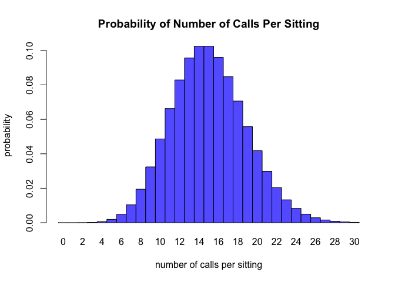

```r
x <- 0:30
l = 15
probset <- dpois (x = x, lambda = l)
barplot(probset, names.arg = x, space = 0, col = "#6666FF", xlab = "number of calls per sitting", ylab = "probability", main = "Probability of Number of Calls Per Sitting")
```

## Simulate 104 results from this distribution (i.e., 2 years of Saturday monitoring sessions).

```r
simulation <- rpois (104, 15) ## use the rpois function to run a simulation. rpois (number of runs, lambda)
simulation ## print
```

```
##   [1] 14 15  8 15 11 18 17 11 19 13 11 15 15 14 11 14 14 12 12 13 14 14 13 15 15
##  [26] 15  9  7 11 15 14 11 19 11 15 14 20  8 12 15 18 11 19 20 17 16 16  6 13 13
##  [51] 12 20 17 21 14  7 14 19 18 20 18 11 16 19  9 15 18 17 18 10 14 13 20 11 15
##  [76] 12 19 10 13  9 19 17 19 14  9 15 10 10 14 15 11  7 16 18 19 16 19 15 14 14
## [101]  9 25 12 12
```

## Plot the simulated results using hist() and use xlim() to set the horizontal limits to be from 0 to 30. How does your histogram compare to the shape of the probability mass function you plotted above?

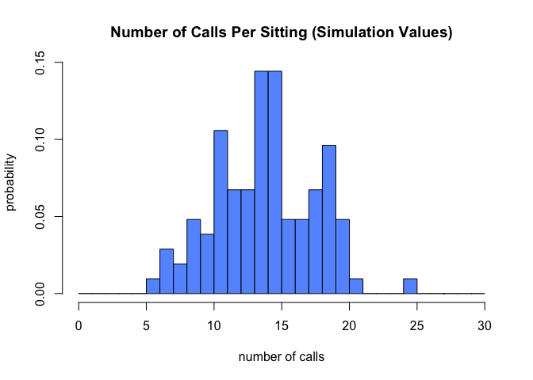

```r
hist(simulation, breaks = seq(0,30,1), probability = TRUE, col = "#6699FF", main = "Number of Calls Per Sitting (Simulation Values)", xlab = "number of calls", ylab = "probability") ## use the hist function to plot the data obtained in the part above.
```

The initial Poisson mass distribution is symmetrical and bell shaped. The simulation distribution is also symmetrical and bell shaped. Both graphs have a peak at around 15 calls.